# Walleye Pollock in BC case study

Sean C. Anderson

Load libraries:

```r
library(sdmTMB)
library(ggplot2)
theme_set(theme_light())
library(dplyr)
```

Load survey data and survey grid:

```r
surveyjoin::cache_data()
```

```
## Skipping: pbs-catch.rds - Local version is up to date
## Skipping: pbs-haul.rds - Local version is up to date
## Skipping: afsc-catch.rds - Local version is up to date
## Skipping: afsc-haul.rds - Local version is up to date
## Skipping: nwfsc-catch.rds - Local version is up to date
## Skipping: nwfsc-haul.rds - Local version is up to date
## ✔ All data for region(s) nwfsc, pbs, and afsc downloaded and cached
```

```r
surveyjoin::load_sql_data()
```

```
## ✔ Raw data read into memory
## ✔ SQLite database created
```

```r
dat <- surveyjoin::get_data("walleye pollock", regions = "pbs") |>
  mutate(year = lubridate::year(lubridate::ymd(date))) |>
  select(survey_name, year, lon_start, lat_start, depth_m, effort, catch_weight, common_name)
dat <- sdmTMB::add_utm_columns(dat, ll_names = c("lon_start", "lat_start"), utm_crs = 3156)
table(dat$survey_name, dat$year)
```

```
##
##            2003 2004 2005 2006 2007 2008 2009 2010 2011 2012 2013 2014 2015
##   SYN HS      0    0  197    0  131    0  155    0  184    0  175    0  148
##   SYN QCS   227  228  219    0  253    0  226    0  244    0  231    0  235
##   SYN WCHG    0    0    0  107  106  116    0  123    0  126    0   53    0
##   SYN WCVI    0   87    0  164    0  160    0  136    0  151    0  146    0
##
##            2016 2017 2018 2019 2020 2021 2022 2023 2024 2025
##   SYN HS      0  137    0  135    0  116    0  148    0  145
##   SYN QCS     0  237    0  239    0  193    0  207    0  202
##   SYN WCHG  108    0  116    0   96    0  107    0  113    0
##   SYN WCVI  140    0  190    0    0  168  126    0  148    0
```

```r
dat <- dat |>
  # Use only complete N/S sampling years
  filter(!(year %in% c(2003, 2004, 2020))) |>
  tidyr::drop_na(effort, catch_weight, depth_m) |>
  # Drop these surveys to be perfectly bienniel
  filter(!(year == 2007 & survey_name == "SYN WCHG")) |>
  filter(!(year == 2021 & survey_name == "SYN WCVI"))
table(dat$survey_name, dat$year)
```

```
##
##            2005 2006 2007 2008 2009 2010 2011 2012 2013 2014 2015 2016 2017
##   SYN HS    189    0  131    0  154    0  183    0  175    0  147    0  136
##   SYN QCS   207    0  249    0  226    0  244    0  230    0  224    0  235
##   SYN WCHG    0  107    0  116    0  123    0  126    0   38    0  108    0
##   SYN WCVI    0  163    0  159    0  124    0  150    0  145    0  140    0
##
##            2018 2019 2021 2022 2023 2024 2025
##   SYN HS      0  135  116    0  148    0  142
##   SYN QCS     0  235  191    0  204    0  202
##   SYN WCHG  116    0    0  107    0  113    0
##   SYN WCVI  190    0    0  126    0  148    0
```

```r
grid <- surveyjoin::dfo_synoptic_grid |>
  sdmTMB::replicate_df("year", unique(dat$year))
grid <- sdmTMB::add_utm_columns(grid, c("lon", "lat"), utm_crs = 3156)

map_data <- rnaturalearth::ne_countries(
  scale = "large",
  returnclass = "sf", country = "canada")
bc_coast <- suppressWarnings(suppressMessages(
  sf::st_crop(map_data,
    c(xmin = -134, ymin = 46, xmax = -120, ymax = 57))))
bc_coast <- sf::st_transform(bc_coast, crs = 3156)
```

```r
table(dat$survey_name, dat$year)
```

```
##
##            2005 2006 2007 2008 2009 2010 2011 2012 2013 2014 2015 2016 2017
##   SYN HS    189    0  131    0  154    0  183    0  175    0  147    0  136
##   SYN QCS   207    0  249    0  226    0  244    0  230    0  224    0  235
##   SYN WCHG    0  107    0  116    0  123    0  126    0   38    0  108    0
##   SYN WCVI    0  163    0  159    0  124    0  150    0  145    0  140    0
##
##            2018 2019 2021 2022 2023 2024 2025
##   SYN HS      0  135  116    0  148    0  142
##   SYN QCS     0  235  191    0  204    0  202
##   SYN WCHG  116    0    0  107    0  113    0
##   SYN WCVI  190    0    0  126    0  148    0
```

We can visualize the raw survey data:

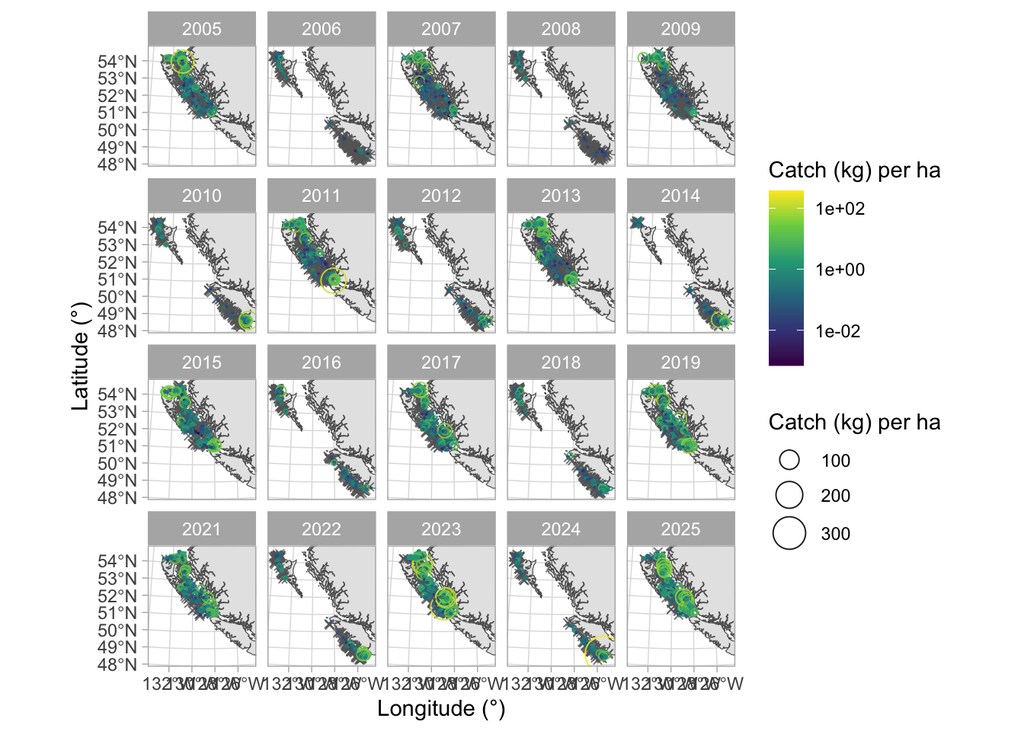

```r
.xlim <- range(dat$X * 1000)
.ylim <- range(dat$Y * 1000)
pos_dat <- filter(dat, catch_weight > 0)
zero_dat <- filter(dat, catch_weight == 0)

ggplot() +
  geom_sf(data = bc_coast) +
  geom_point(data = zero_dat,
    mapping = aes(X * 1000, Y * 1000),
    pch = 4,
    alpha = 0.8,
    colour = "grey40"
  ) +
  geom_point(data = pos_dat,
    mapping = aes(X * 1000, Y * 1000,
      size = catch_weight / effort,
      colour = catch_weight / effort),
    pch = 21,
    alpha = 0.9
  ) +
  facet_wrap(~year) +
  scale_colour_viridis_c(trans = "log10") +
  scale_size_area(max_size = 8) +
  coord_sf(xlim = .xlim, ylim = .ylim) +
  labs(colour = "Catch (kg) per ha", size = "Catch (kg) per ha") +
  xlab("Longitude (°)") + ylab("Latitude (°)")
```

Set up a finite-element mesh to implement the SPDE approach:

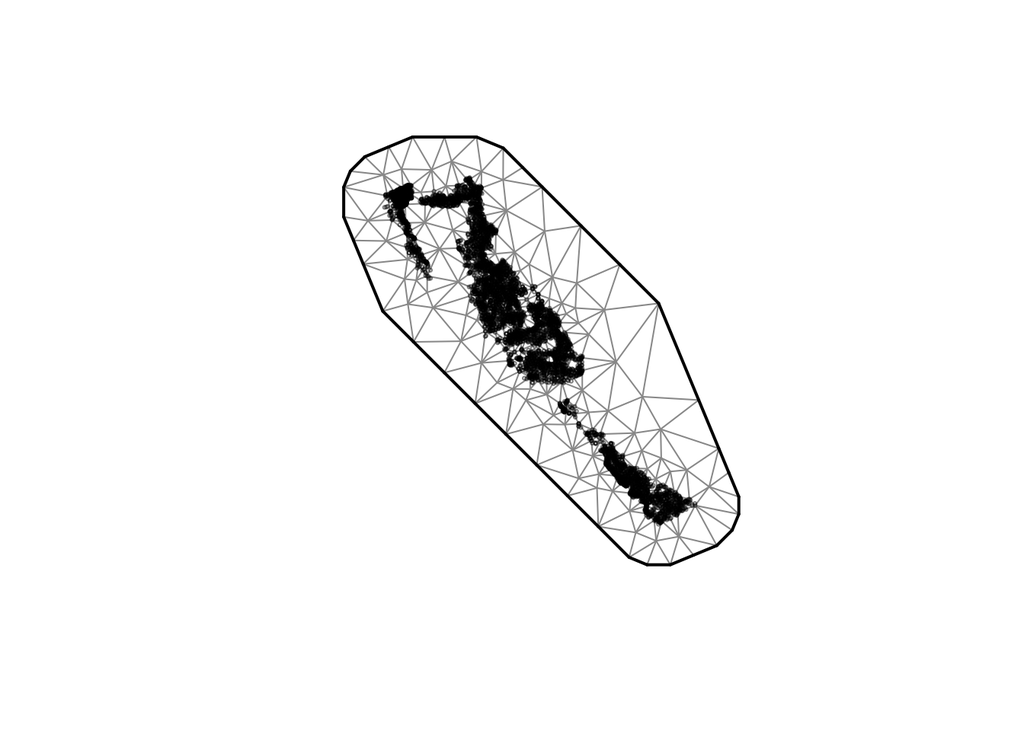

```r
mesh <- make_mesh(dat, c("X", "Y"), cutoff = 15)
plot(mesh)
```

We’ll initialize an empty list to store our model fits:

```r
fits <- list()
```

First, we’ll fit a standard spatiotemporal model with independent year effects, a spatial GMRF, and independent spatiotemporal GMRFs:

```r
fits[[1]] <- sdmTMB(
  catch_weight ~ 0 + factor(year),
  data = dat,
  mesh = mesh,
  offset = log(dat$effort),
  family = delta_gamma(type = "poisson-link"),
  time = "year",
  spatial = "on",
  spatiotemporal = "iid",
  share_range = TRUE,
  anisotropy = TRUE,
  silent = FALSE
)
```

[output not shown]

[output cut: 640 more lines]

[output not shown]

```
## attempting to improve convergence with Newton update(s)
```

[output not shown]

[output cut: 342 more lines]

[output not shown]

```
## accepting parameters from Newton update
## running TMB sdreport
```

[output not shown]

[output cut: 340 more lines]

[output not shown]

```r
names(fits)[[1]] <- "IID RF, factor(year)"
```

We can inspect this model with some basic diagnostics:

```r
print(fits[[1]])
```

[output not shown]

[output cut: 15 more lines]

```
## factor(year)2021     1.04    0.29
## factor(year)2022     1.15    0.40
## factor(year)2023     1.31    0.29
## factor(year)2024     0.69    0.37
## factor(year)2025     1.20    0.29
##
## Dispersion parameter: 0.78
## Matérn anisotropic range (spatial): 18.8 to 50.8 at 98 deg.
## Spatial SD: 1.18
## Spatiotemporal IID SD: 1.23
##
## ML criterion at convergence: 13064.524
##
## See ?tidy.sdmTMB to extract these values as a data frame.
## See ?plot_anisotropy to plot the anisotropic range.
```

```r
sanity(fits[[1]])
```

```
## ✔ Non-linear minimizer suggests successful convergence
```

```
## ✔ Hessian matrix is positive definite
```

```
## ✔ No extreme or very small eigenvalues detected
```

```
## ✔ No gradients with respect to fixed effects are >= 0.001
```

```
## ✔ No fixed-effect standard errors are NA
```

```
## ✔ No standard errors look unreasonably large
```

```
## ✔ No sigma parameters are < 0.01
```

```
## ✔ No sigma parameters are > 100
```

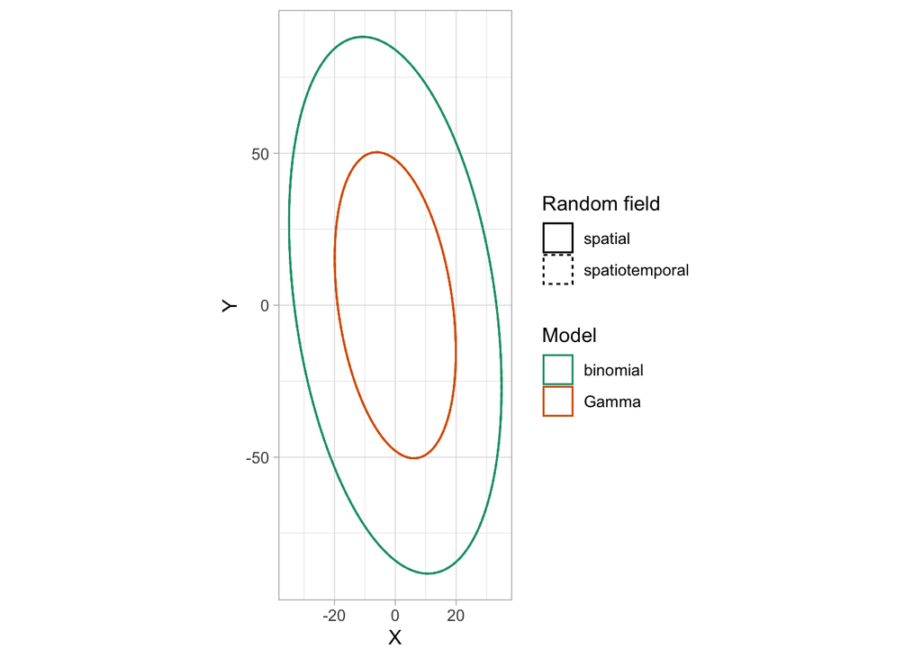

```r
plot_anisotropy(fits[[1]])
```

```r
set.seed(1)
simulate(fits[[1]], nsim = 200, type = "mle-mvn") |>
  dharma_residuals(fits[[1]])
```

[output not shown]

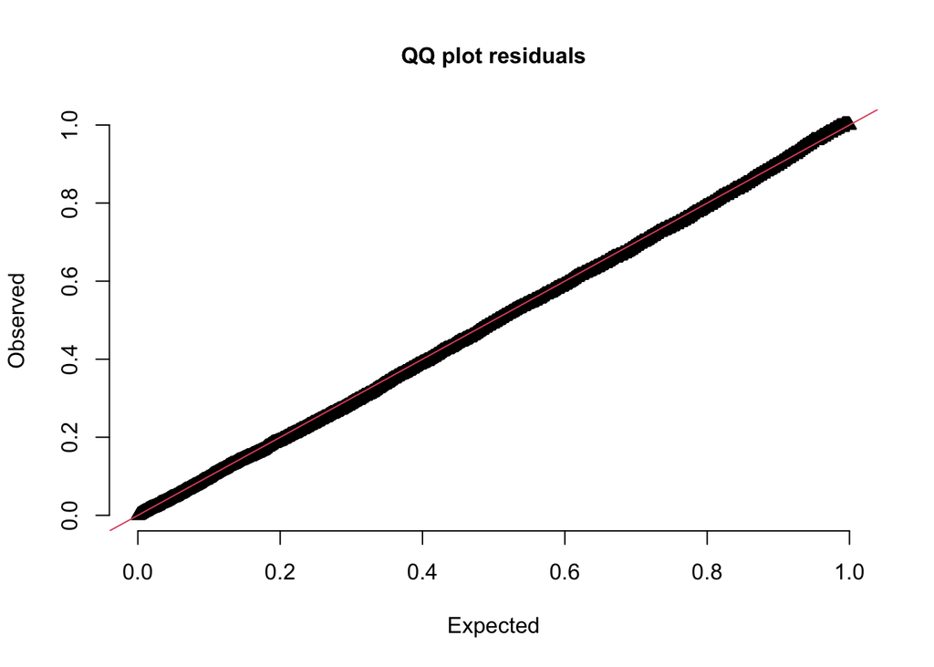

We can calculate a relative biomass index from this model fit by predicting from our model onto the survey grid each year and summing predicting density across the domain:

```r
pred <- predict(fits[[1]], newdata = grid, return_tmb_obj = TRUE)
```

```
## Fitted object contains an offset but the offset is `NULL` in `predict.sdmTMB()`
## and `newdata` were supplied.
## Prediction will proceed assuming the offset vector is 0 in the prediction.
## Specify an offset vector in `predict.sdmTMB()` to override this.
```

```r
ind <- get_index(pred)
```

Make a look-up table to keep track of even years for plotting:

```r
lu <- data.frame(year = sort(unique(dat$year)))
lu$even <- lu$year %% 2 == 0
lu$survey_group <- ifelse(lu$even, "WCHG + WCVI", "QCS + HS")
```

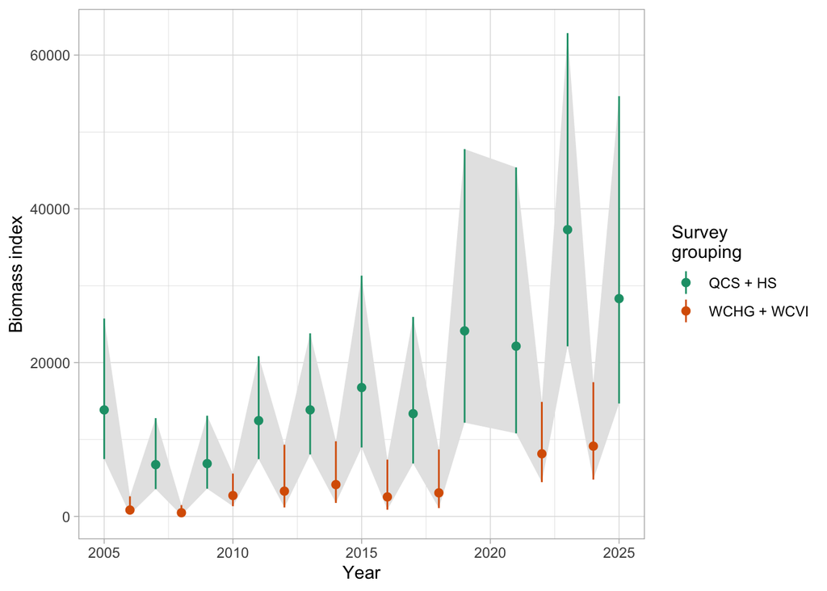

```r
ind |>
  left_join(lu) |>
  ggplot(aes(year, est, ymin = lwr, ymax = upr)) +
  geom_ribbon(fill = "grey90") +
  geom_linerange(aes(colour = survey_group)) +
  geom_point(aes(colour = survey_group), size = 2) +
  scale_colour_brewer(palette = "Dark2") +
  ylab("Biomass index") + xlab("Year") + labs(colour = "Survey\ngrouping")
```

Next, we’ll fit a sequence of alternative models

```r
fits[[2]] <- update(
  fits[[1]],
  formula. = . ~ 1,
  spatiotemporal = "rw"
)
```

```
## Detected irregular time spacing with an AR(1), random walk, or time-indexed
## nonlocal process.
## Consider filling in the missing time slices with `extra_time`.
## `extra_time = c(2020)`
```

[output not shown]

[output cut: 544 more lines]

[output not shown]

```
## attempting to improve convergence with Newton update(s)
```

[output not shown]

[output cut: 37 more lines]

[output not shown]

```
## retaining parameters from before Newton update
## and skipping further Newton updates
## running TMB sdreport
```

[output not shown]

[output cut: 36 more lines]

[output not shown]

```r
names(fits)[[2]] <- "RW RF"
```

```r
fits[[3]] <- update(
  fits[[1]],
  formula. = . ~ 1,
  spatiotemporal = "ar1"
)
```

```
## Detected irregular time spacing with an AR(1), random walk, or time-indexed
## nonlocal process.
## Consider filling in the missing time slices with `extra_time`.
## `extra_time = c(2020)`
```

[output not shown]

[output cut: 444 more lines]

[output not shown]

```
## attempting to improve convergence with Newton update(s)
```

[output not shown]

[output cut: 53 more lines]

[output not shown]

```
## accepting parameters from Newton update
## running TMB sdreport
```

[output not shown]

[output cut: 52 more lines]

[output not shown]

```r
names(fits)[[3]] <- "AR1 RF"
```

```r
fits[[4]] <- update(
  fits[[1]],
  formula. = . ~ 1,
  spatiotemporal = "rw",
  time_varying = ~ 1,
  time_varying_type = "rw0",
  priors = sdmTMBpriors(sigma_V = gamma_cv(0.3, 0.5))
)
```

```
## Detected irregular time spacing with an AR(1), random walk, or time-indexed
## nonlocal process.
## Consider filling in the missing time slices with `extra_time`.
## `extra_time = c(2020)`
```

[output not shown]

[output cut: 549 more lines]

[output not shown]

```
## attempting to improve convergence with Newton update(s)
```

[output not shown]

[output cut: 53 more lines]

[output not shown]

```
## retaining parameters from before Newton update
## and skipping further Newton updates
## running TMB sdreport
```

[output not shown]

[output cut: 52 more lines]

[output not shown]

```r
names(fits)[[4]] <- "RW RF, RW year"
```

```r
fits[[5]] <- update(
  fits[[1]],
  formula. = . ~ 1,
  spatiotemporal = "ar1",
  time_varying = ~ 1,
  time_varying_type = "rw0",
  priors = sdmTMBpriors(sigma_V = gamma_cv(0.3, 0.5))
)
```

```
## Detected irregular time spacing with an AR(1), random walk, or time-indexed
## nonlocal process.
## Consider filling in the missing time slices with `extra_time`.
## `extra_time = c(2020)`
```

[output not shown]

[output cut: 508 more lines]

[output not shown]

```
## attempting to improve convergence with Newton update(s)
```

[output not shown]

[output cut: 70 more lines]

[output not shown]

```
## accepting parameters from Newton update
## running TMB sdreport
```

[output not shown]

[output cut: 68 more lines]

[output not shown]

```r
names(fits)[[5]] <- "AR1 RF, RW year"
```

```r
fits[[6]] <- update(
  fits[[1]],
  formula. = . ~ 1,
  spatiotemporal = "iid",
  time_varying = ~ 1,
  time_varying_type = "rw0",
  priors = sdmTMBpriors(sigma_V = gamma_cv(0.3, 0.5))
)
```

```
## Detected irregular time spacing with an AR(1), random walk, or time-indexed
## nonlocal process.
## Consider filling in the missing time slices with `extra_time`.
## `extra_time = c(2020)`
```

[output not shown]

[output cut: 494 more lines]

[output not shown]

```
## attempting to improve convergence with Newton update(s)
```

[output not shown]

[output cut: 54 more lines]

[output not shown]

```
## accepting parameters from Newton update
## running TMB sdreport
```

[output not shown]

[output cut: 52 more lines]

[output not shown]

```r
names(fits)[[6]] <- "IID RF, RW year"
```

```r
fits[[7]] <- update(
  fits[[1]],
  formula. = . ~ 1,
  spatiotemporal = "off",
  time_varying = ~ 1,
  time_varying_type = "rw0",
  priors = sdmTMBpriors(sigma_V = gamma_cv(0.3, 0.5))
)
```

```
## Detected irregular time spacing with an AR(1), random walk, or time-indexed
## nonlocal process.
## Consider filling in the missing time slices with `extra_time`.
## `extra_time = c(2020)`
```

[output not shown]

[output cut: 339 more lines]

[output not shown]

```
## attempting to improve convergence with Newton update(s)
```

[output not shown]

[output cut: 37 more lines]

[output not shown]

```
## accepting parameters from Newton update
## running TMB sdreport
```

[output not shown]

[output cut: 36 more lines]

[output not shown]

```r
names(fits)[[7]] <- "Spatial only, RW year"
```

Iterate through our fits to grab the biomass index:

```r
future::plan(future::multisession, workers = 2L)
indexes <- furrr::future_map_dfr(fits, \(x) {
  pred <- predict(x, newdata = grid, return_tmb_obj = TRUE)
  get_index(pred)
}, .id = "model", .options = furrr::furrr_options(seed = TRUE))
```

[output not shown]

[output not shown]

```r
future::plan(future::sequential)
```

```r
saveRDS(indexes, file = "data-generated/bc-indexes-lingcod.rds")
indexes <- readRDS("data-generated/bc-indexes-lingcod.rds")
```

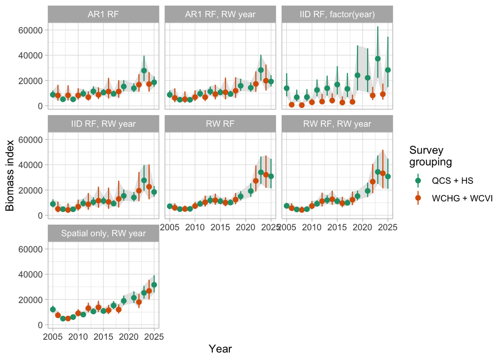

```r
indexes |>
  left_join(lu) |>
  ggplot(aes(year, est, ymin = lwr, ymax = upr)) +
  geom_ribbon(fill = "grey90") +
  geom_linerange(aes(colour = survey_group)) +
  geom_point(aes(colour = survey_group), size = 2) +
  scale_colour_brewer(palette = "Dark2") +
  facet_wrap(~model) +
  ylab("Biomass index") + xlab("Year") + labs(colour = "Survey\ngrouping")
```

Test for seesaw index on these time series:

```r
period2_metric <- function(x, year = seq_along(x), conf = 0.95) {
  stopifnot(
    length(x) == length(year),
    all(x > 0)
  )

  y <- log(x)

  # Alternating survey phases, coded so beta is the phase difference
  phase <- ifelse(year %% 2 == 0, 0.5, -0.5)
  # period2 <- (-1)^year

  fit <- lm(y ~ year + phase)

  beta <- coef(fit)[["phase"]]
  beta_se <- coef(summary(fit))["phase", "Std. Error"]
  ci <- confint(fit, "phase", level = conf)
  A_fun <- \(b) 100 * (exp(abs(b)) - 1)
  A_ci <- A_fun(ci)
  A_bounds <- if (ci[1L] <= 0 && ci[2L] >= 0) {
    c(0, max(A_ci))
  } else {
    range(A_ci)
  }

  c(
    beta = beta,
    beta_se = beta_se,
    beta_lower = ci[1L],
    beta_upper = ci[2L],
    A = A_fun(beta),
    A_lower = A_bounds[1L],
    A_upper = A_bounds[2L]
  )
}

moving_window <- function(x, year, window = 10L, ...) {
  n <- length(x)

  out <- lapply(seq_len(n - window + 1L), function(i) {
    ind <- i:(i + window - 1L)

    res <- period2_metric(
      x = x[ind],
      year = year[ind],
      ...
    )

    data.frame(
      start = year[ind[1L]],
      end = year[ind[length(ind)]],
      t(res)
    )
  })

  do.call(rbind, out)
}
```

```r
seesaw_indexes <- indexes |>
  arrange(model, year) |>
  group_by(model) |>
  group_modify(\(.x, .y) {
    moving_window(.x$est, year = .x$year, window = 8L)
  }) |>
  ungroup()
```

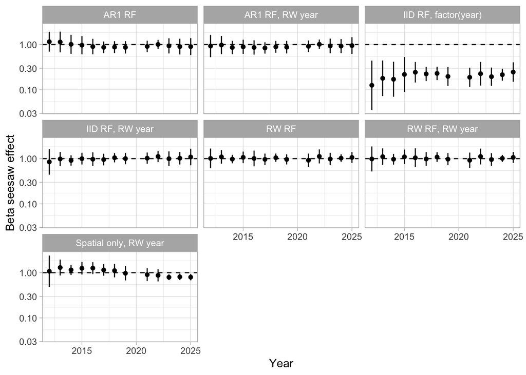

```r
seesaw_indexes |>
  mutate(year = end) |>
  ggplot(aes(year, exp(beta))) +
  geom_hline(yintercept = 1, lty = 2) +
  geom_linerange(aes(x = year, ymin = exp(beta_lower), ymax = exp(beta_upper))) +
  geom_point() +
  facet_wrap(~model) +
  xlab("Year") +
  ylab("Beta seesaw effect") +
  scale_y_log10()
```

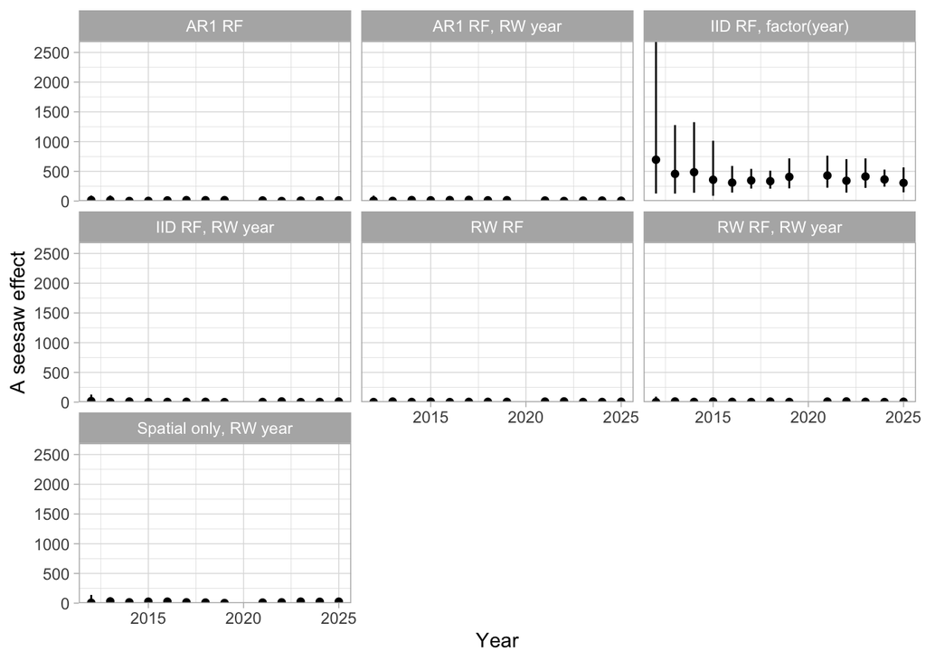

```r
seesaw_indexes |>
  mutate(year = end) |>
  ggplot(aes(year, A)) +
  geom_linerange(aes(x = year, ymin = A_lower, ymax = A_upper)) +
  geom_point() +
  facet_wrap(~model) +
  xlab("Year") +
  scale_y_continuous(expand = c(0, NA)) +
  ylab("A seesaw effect")
```

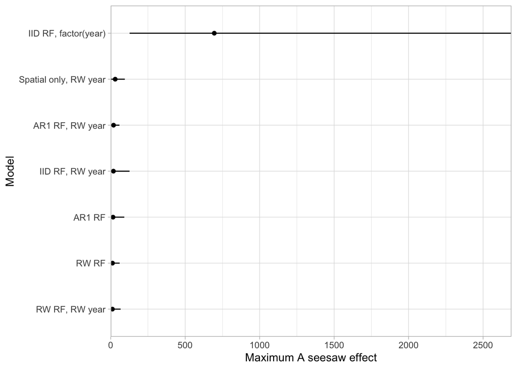

```r
seesaw_indexes |>
  group_by(model) |>
  slice_max(A, n = 1L, with_ties = FALSE) |>
  ungroup() |>
  mutate(model = reorder(model, A)) |>
  ggplot(aes(y = model)) +
  geom_linerange(aes(xmin = A_lower, xmax = A_upper), orientation = "y") +
  geom_point(aes(x = A)) +
  scale_x_continuous(expand = c(0, NA)) +
  xlab("Maximum A seesaw effect") +
  ylab("Model")
```

## Check influence of the random walk prior

```r
prior_grid <- tidyr::crossing(
  mean = c(0.1, 0.3, 0.6),
  cv = c(0.2, 0.5, 1)
) |>
  mutate(prior = paste0("mean = ", mean, ", CV = ", cv))

prior_indexes <- purrr::map_dfr(seq_len(nrow(prior_grid)), \(i) {
  fit <- update(
    fits[["IID RF, RW year"]],
    priors = sdmTMBpriors(
      sigma_V = gamma_cv(prior_grid$mean[[i]], prior_grid$cv[[i]])
    )
  )
  pred <- predict(fit, newdata = grid, return_tmb_obj = TRUE)
  get_index(pred) |>
    mutate(prior = prior_grid$prior[[i]])
})
```

```
## Detected irregular time spacing with an AR(1), random walk, or time-indexed
## nonlocal process.
## Consider filling in the missing time slices with `extra_time`.
## `extra_time = c(2020)`
```

[output not shown]

[output cut: 383 more lines]

[output not shown]

```
## attempting to improve convergence with Newton update(s)
```

[output not shown]

[output cut: 54 more lines]

[output not shown]

```
## accepting parameters from Newton update
## running TMB sdreport
```

[output not shown]

[output cut: 52 more lines]

[output not shown]

```
## Fitted object contains an offset but the offset is `NULL` in `predict.sdmTMB()`
## and `newdata` were supplied.
## Prediction will proceed assuming the offset vector is 0 in the prediction.
## Specify an offset vector in `predict.sdmTMB()` to override this.
## Detected irregular time spacing with an AR(1), random walk, or time-indexed
## nonlocal process.
## Consider filling in the missing time slices with `extra_time`.
## `extra_time = c(2020)`
```

[output not shown]

[output cut: 424 more lines]

[output not shown]

```
## attempting to improve convergence with Newton update(s)
```

[output not shown]

[output cut: 54 more lines]

[output not shown]

```
## accepting parameters from Newton update
## running TMB sdreport
```

[output not shown]

[output cut: 52 more lines]

[output not shown]

```
## Fitted object contains an offset but the offset is `NULL` in `predict.sdmTMB()`
## and `newdata` were supplied.
## Prediction will proceed assuming the offset vector is 0 in the prediction.
## Specify an offset vector in `predict.sdmTMB()` to override this.
## Detected irregular time spacing with an AR(1), random walk, or time-indexed
## nonlocal process.
## Consider filling in the missing time slices with `extra_time`.
## `extra_time = c(2020)`
```

[output not shown]

[output cut: 485 more lines]

[output not shown]

```
## attempting to improve convergence with Newton update(s)
```

[output not shown]

[output cut: 51 more lines]

[output not shown]

```
## accepting parameters from Newton update
## running TMB sdreport
```

[output not shown]

[output cut: 50 more lines]

[output not shown]

```
## Fitted object contains an offset but the offset is `NULL` in `predict.sdmTMB()`
## and `newdata` were supplied.
## Prediction will proceed assuming the offset vector is 0 in the prediction.
## Specify an offset vector in `predict.sdmTMB()` to override this.
## Detected irregular time spacing with an AR(1), random walk, or time-indexed
## nonlocal process.
## Consider filling in the missing time slices with `extra_time`.
## `extra_time = c(2020)`
```

[output not shown]

[output cut: 512 more lines]

[output not shown]

```
## attempting to improve convergence with Newton update(s)
```

[output not shown]

[output cut: 54 more lines]

[output not shown]

```
## accepting parameters from Newton update
## running TMB sdreport
```

[output not shown]

[output cut: 52 more lines]

[output not shown]

```
## Fitted object contains an offset but the offset is `NULL` in `predict.sdmTMB()`
## and `newdata` were supplied.
## Prediction will proceed assuming the offset vector is 0 in the prediction.
## Specify an offset vector in `predict.sdmTMB()` to override this.
## Detected irregular time spacing with an AR(1), random walk, or time-indexed
## nonlocal process.
## Consider filling in the missing time slices with `extra_time`.
## `extra_time = c(2020)`
```

[output not shown]

[output cut: 494 more lines]

[output not shown]

```
## attempting to improve convergence with Newton update(s)
```

[output not shown]

[output cut: 54 more lines]

[output not shown]

```
## accepting parameters from Newton update
## running TMB sdreport
```

[output not shown]

[output cut: 52 more lines]

[output not shown]

```
## Fitted object contains an offset but the offset is `NULL` in `predict.sdmTMB()`
## and `newdata` were supplied.
## Prediction will proceed assuming the offset vector is 0 in the prediction.
## Specify an offset vector in `predict.sdmTMB()` to override this.
## Detected irregular time spacing with an AR(1), random walk, or time-indexed
## nonlocal process.
## Consider filling in the missing time slices with `extra_time`.
## `extra_time = c(2020)`
```

[output not shown]

[output cut: 514 more lines]

[output not shown]

```
## attempting to improve convergence with Newton update(s)
```

[output not shown]

[output cut: 51 more lines]

[output not shown]

```
## accepting parameters from Newton update
## running TMB sdreport
```

[output not shown]

[output cut: 50 more lines]

[output not shown]

```
## Fitted object contains an offset but the offset is `NULL` in `predict.sdmTMB()`
## and `newdata` were supplied.
## Prediction will proceed assuming the offset vector is 0 in the prediction.
## Specify an offset vector in `predict.sdmTMB()` to override this.
## Detected irregular time spacing with an AR(1), random walk, or time-indexed
## nonlocal process.
## Consider filling in the missing time slices with `extra_time`.
## `extra_time = c(2020)`
```

[output not shown]

[output cut: 420 more lines]

[output not shown]

```
## attempting to improve convergence with Newton update(s)
```

[output not shown]

[output cut: 54 more lines]

[output not shown]

```
## accepting parameters from Newton update
## running TMB sdreport
```

[output not shown]

[output cut: 52 more lines]

[output not shown]

```
## Fitted object contains an offset but the offset is `NULL` in `predict.sdmTMB()`
## and `newdata` were supplied.
## Prediction will proceed assuming the offset vector is 0 in the prediction.
## Specify an offset vector in `predict.sdmTMB()` to override this.
## Detected irregular time spacing with an AR(1), random walk, or time-indexed
## nonlocal process.
## Consider filling in the missing time slices with `extra_time`.
## `extra_time = c(2020)`
```

[output not shown]

[output cut: 427 more lines]

[output not shown]

```
## attempting to improve convergence with Newton update(s)
```

[output not shown]

[output cut: 54 more lines]

[output not shown]

```
## accepting parameters from Newton update
## running TMB sdreport
```

[output not shown]

[output cut: 52 more lines]

[output not shown]

```
## Fitted object contains an offset but the offset is `NULL` in `predict.sdmTMB()`
## and `newdata` were supplied.
## Prediction will proceed assuming the offset vector is 0 in the prediction.
## Specify an offset vector in `predict.sdmTMB()` to override this.
## Detected irregular time spacing with an AR(1), random walk, or time-indexed
## nonlocal process.
## Consider filling in the missing time slices with `extra_time`.
## `extra_time = c(2020)`
```

[output not shown]

[output cut: 436 more lines]

[output not shown]

```
## attempting to improve convergence with Newton update(s)
```

[output not shown]

[output cut: 51 more lines]

[output not shown]

```
## retaining parameters from before Newton update
## and skipping further Newton updates
## running TMB sdreport
```

[output not shown]

[output cut: 50 more lines]

[output not shown]

```
## Fitted object contains an offset but the offset is `NULL` in `predict.sdmTMB()`
## and `newdata` were supplied.
## Prediction will proceed assuming the offset vector is 0 in the prediction.
## Specify an offset vector in `predict.sdmTMB()` to override this.
```

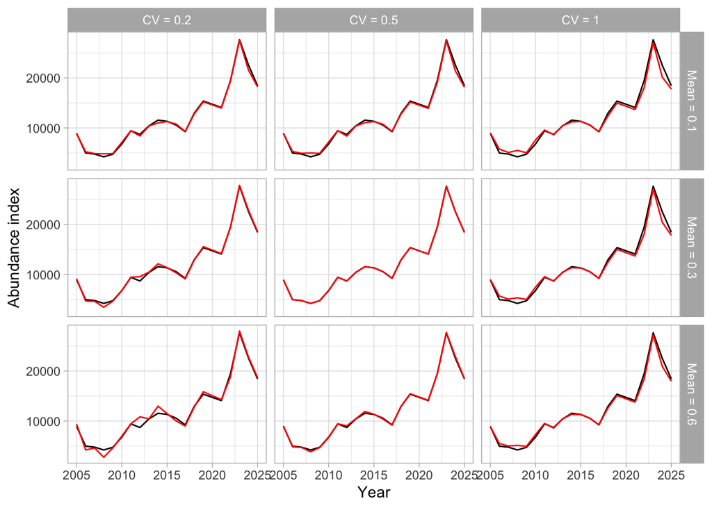

```r
prior_indexes <- prior_indexes |>
  tidyr::extract(
    prior,
    into = c("prior_mean", "prior_cv"),
    regex = "mean = ([0-9.]+), CV = ([0-9.]+)",
    convert = TRUE,
    remove = FALSE
  ) |>
    mutate(prior_mean = paste("Mean =", prior_mean)) |>
    mutate(prior_cv = paste("CV =", prior_cv))

ggplot(prior_indexes, aes(year, est, group = prior)) +
  geom_line(data = filter(prior_indexes, prior == "mean = 0.3, CV = 0.5") |> select(year, est), colour = "black", inherit.aes = FALSE, mapping = aes(x = year, y = est)) +
  geom_line(colour = "red") +
  facet_grid(prior_mean ~ prior_cv) +
  labs(
    x = "Year",
    y = "Abundance index"
  )
```

it’s nice because you can also apply it to the simulated data by working with the estimated minus true values (residuals) without the detrending part - in fact, it works out to the same thing I was doing with the simulated data, just not in lm() form because it’s fit as a model, you get a CI that helps tell you if you have ‘significant’ seesawing happening you could use s(year) if you wanted a non-linear detrending, but for 8-10 years that seems overkill here

I’m also slowly converging on the thinking that we should probably have time_varying intercepts in these models, not just random walk random fields on their own. They seem to do a pretty good job — they just need a prior to help convergence. Whether the fields should be IID or RW may depend more on the intended purpose. [4:18 PM]maybe IID fields for things like stock assessment and RW fields for things like SOPO where we are happy to smooth through the pattern and induce more year-to-year correlation [4:19 PM]I was writing the methods, and writing always makes you think more about these things [4:20 PM]and as long as the gamma prior on the time-varying SD has a wide enough CV it doesn’t seem too influential